# Nonlinear Methods: Fitting Regression Trees

## Regression/Classification Trees

Tree based method:

- Split up predictor space into regions, different predictions for each region
- Classification tree if goal is to classify (predict) group membership
  - For a given region, usually use most prevalent class as prediction
- Regression tree if goal is to predict a continuous response
  - For a given region, usually use mean of observations as prediction

## Back to Regression Trees: How do we fit them?

- Assuming we want to model a constant in each region, the mean is the optimal predictor
- How do we pick our splits?
  - Fit using recursive binary splitting - a greedy algorithm
  - For every possible value of each predictor, find Residual Sum of Squares and try to minimize that

  \[R_1(j, s) = \{x|x_j < s\}\mbox{ and }R_2(j, s) = \{x|x_j \geq s\}\]
  - we seek the value of j and s that minimize the equation

\[\sum_{i:x_i\in R_1(j,s)}(y_i-\bar{y}_{R_1})^2+\sum_{i:x_i\in R_2(j,s)}(y_i-\bar{y}_{R_2})^2\]

## Basic Tree Fit

Using Voting data set, predicting income via percent with college degree

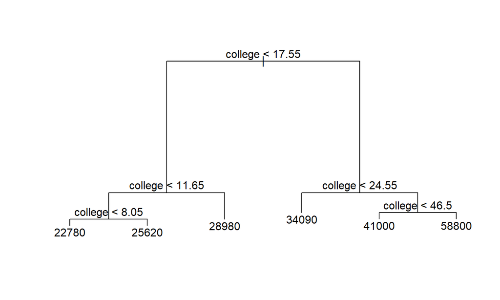

```r
treeFit <- tree(income ~ college, data = voting)
plot(treeFit)
text(treeFit) #first optimal split is 17.55
```

## Visual of Regression Tree Fits

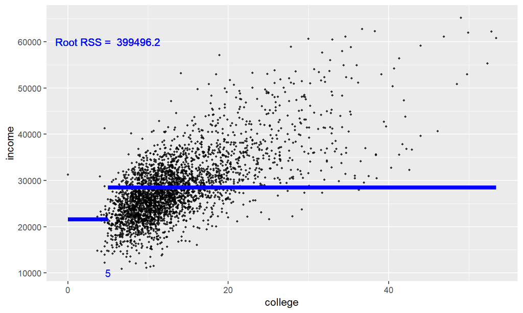

## Visual of Regression Tree Fits

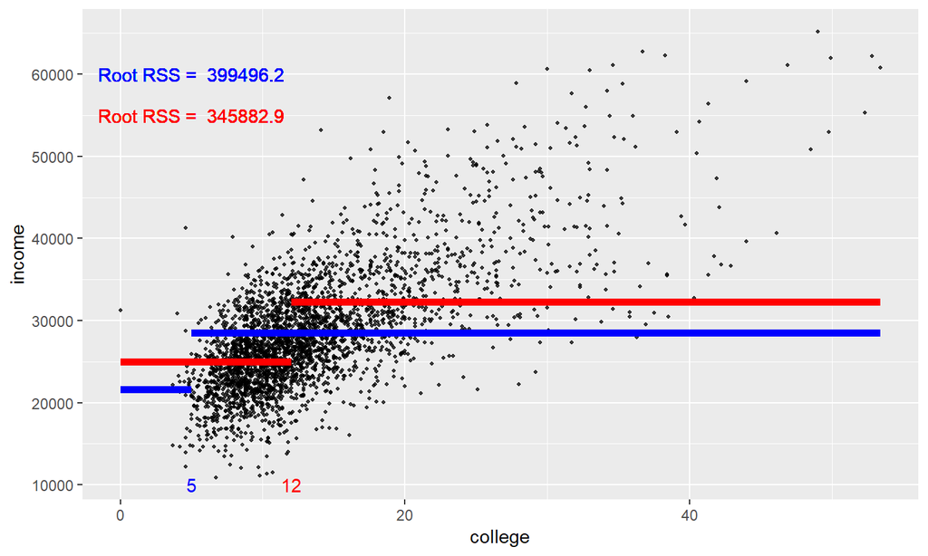

## Visual of Regression Tree Fits

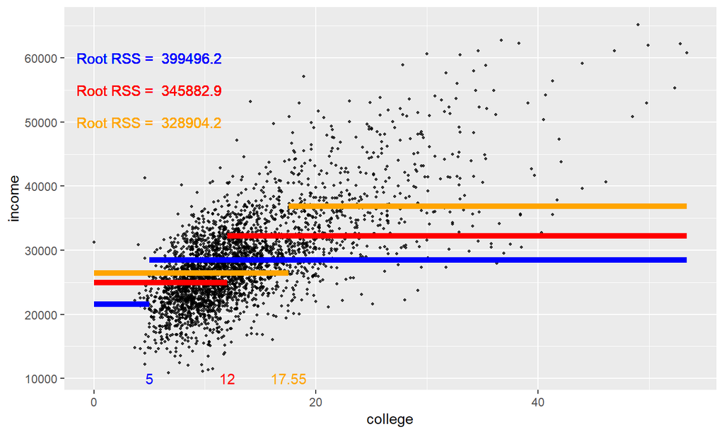

## Visual of Regression Tree Fits

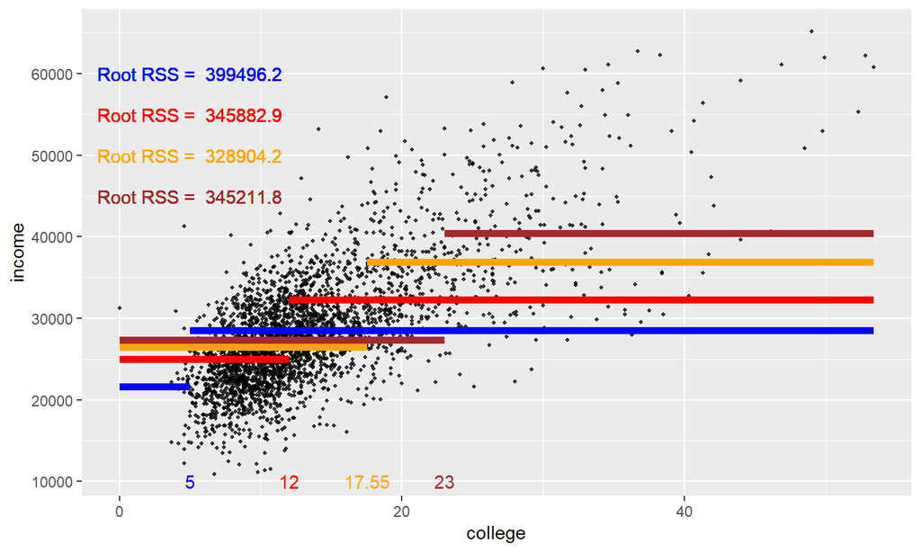

## Fitting Regression Trees

- Once that split is chosen, the same process is used to create the second split
- Generally grow a `large' tree (many nodes)
- Tree then usually pruned back using cost-complexity pruning
  - Done to not overfit data
  - Prune back increases bias but decreases variance, hopefully improving prediction
- Generally, can choose number of nodes using training/test set and comparing or using a method like cross-validation

## Regression Tree Example

Consider the diamonds data set from the `ggplot2` package

Let's try to predict price

```r
diamonds
```

```
## # A tibble: 53,940 x 10
##   carat cut     color clarity depth table price     x     y     z
##   <dbl> <ord>   <ord> <ord>   <dbl> <dbl> <int> <dbl> <dbl> <dbl>
## 1 0.23  Ideal   E     SI2      61.5    55   326  3.95  3.98  2.43
## 2 0.21  Premium E     SI1      59.8    61   326  3.89  3.84  2.31
## 3 0.23  Good    E     VS1      56.9    65   327  4.05  4.07  2.31
## 4 0.290 Premium I     VS2      62.4    58   334  4.2   4.23  2.63
## 5 0.31  Good    J     SI2      63.3    58   335  4.34  4.35  2.75
## # ... with 5.394e+04 more rows
```

## Regression Tree Example

Obtain training and test sets

```r
set.seed(90)
train <- sample(1:nrow(diamonds), size = nrow(diamonds)*0.8)
test <- dplyr::setdiff(1:nrow(diamonds), train)

diamondsTrain <- diamonds[train, ]
diamondsTest <- diamonds[test, ]
```

## Regression Tree Example

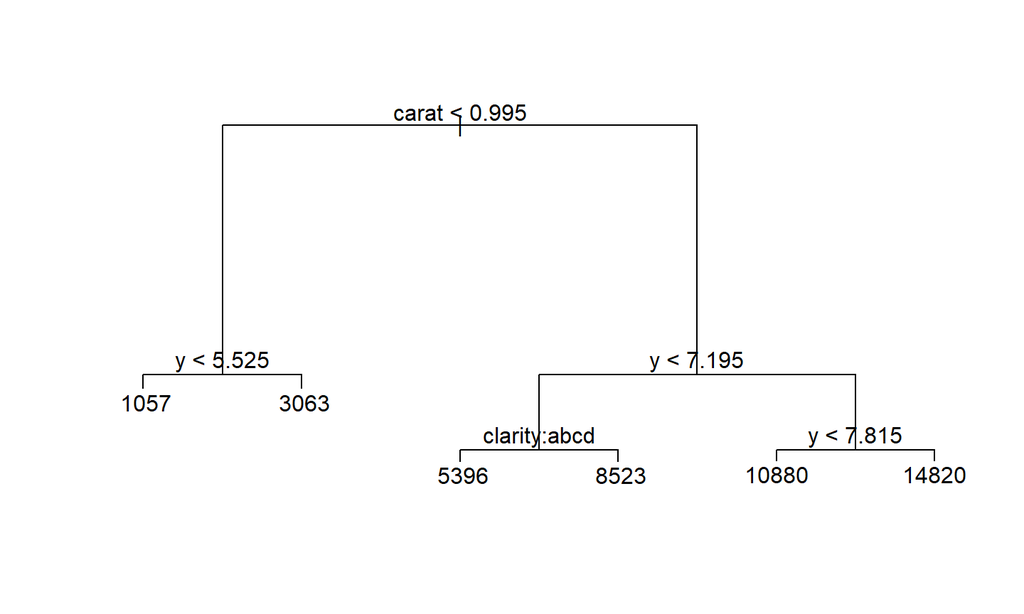

```r
treeFit <- tree(price ~ ., data = diamondsTrain)
plot(treeFit); text(treeFit)
```

## Regression Tree Example

- `$dev` represents CV error, choose minimim
- Here largest model, no pruning needed

```r
cvTree <- cv.tree(treeFit); cvTree
```

```
## $size
## [1] 6 5 4 3 2 1
##
## $dev
## [1]  82209762165 117537472058 117537472058 140454629021 266024826995
## [6] 681004362571
##
## $k
## [1]         -Inf  17470068915  18275477411  22965767180 125570783963
## [6] 414996131911
##
## $method
## [1] "deviance"
##
## attr(,"class")
## [1] "prune"         "tree.sequence"
```

## Visual of How CV Error Changes w/# of Nodes

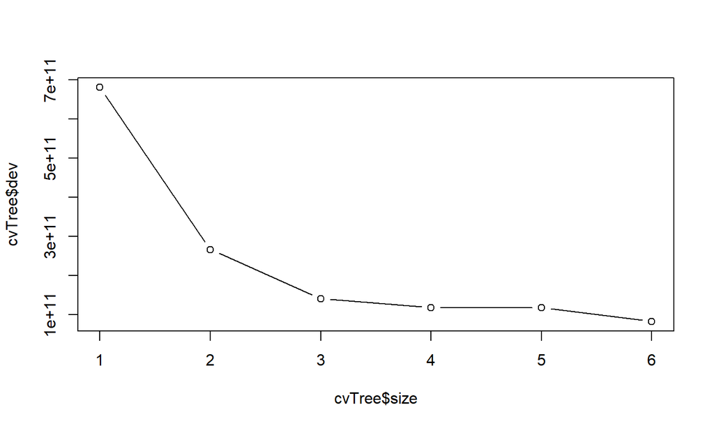

```r
plot(cvTree$size ,cvTree$dev ,type="b")
```

## Regression Tree Example

- Predictions using `predict`

```r
pred <- predict(treeFit, newdata = dplyr::select(diamondsTest, -price))
```

- Root MSE

```r
sqrt(mean((pred-diamondsTest$price)^2))
```

```
## [1] 1404.678
```